# Auto

**Index**  
1. Chapter 2 - Exercise 9  
2. Chapter 3 - Exercise 8  
3. Chapter 3 - Exercise 9  
4. Chapter 4 - Exercise 14

We consider only complete observations:

```r
Auto=read.csv('data/Auto.csv',header=TRUE, na.strings = '?')
Auto=na.omit(Auto)
```

Visualize:

```r
View(Auto)
fix(Auto)
```

Dimension: rows x columns

```r
dim(Auto)
```

```
[1] 392   9
```

List of variables and fix them.

```r
names(Auto)
```

```
[1] "mpg"          "cylinders"    "displacement" "horsepower"   "weight"       "acceleration" "year"
[8] "origin"       "name"
```

```r
attach(Auto)
```

# Chapter 2 - Exercise 9

1. Which of the predictors are quantitative, and which are qualitative?

Dataset summary

```r
summary(Auto)
```

```
      mpg          cylinders      displacement     horsepower        weight      acceleration
 Min.   : 9.00   Min.   :3.000   Min.   : 68.0   Min.   : 46.0   Min.   :1613   Min.   : 8.00
 1st Qu.:17.00   1st Qu.:4.000   1st Qu.:105.0   1st Qu.: 75.0   1st Qu.:2225   1st Qu.:13.78
 Median :22.75   Median :4.000   Median :151.0   Median : 93.5   Median :2804   Median :15.50
 Mean   :23.45   Mean   :5.472   Mean   :194.4   Mean   :104.5   Mean   :2978   Mean   :15.54
 3rd Qu.:29.00   3rd Qu.:8.000   3rd Qu.:275.8   3rd Qu.:126.0   3rd Qu.:3615   3rd Qu.:17.02
 Max.   :46.60   Max.   :8.000   Max.   :455.0   Max.   :230.0   Max.   :5140   Max.   :24.80

      year           origin                      name
 Min.   :70.00   Min.   :1.000   amc matador       :  5
 1st Qu.:73.00   1st Qu.:1.000   ford pinto        :  5
 Median :76.00   Median :1.000   toyota corolla    :  5
 Mean   :75.98   Mean   :1.577   amc gremlin       :  4
 3rd Qu.:79.00   3rd Qu.:2.000   amc hornet        :  4
 Max.   :82.00   Max.   :3.000   chevrolet chevette:  4
                                 (Other)           :365
```

Quantitative: mpg, cylinders, displacement, horsepower, weight, acceleration, year, origin  
Qualitative: name

2. What is the range of each quantitative predictor? You can answer this using the range() function.

```r
for (i in 1:8){
  print(paste(names(Auto[i]),range(Auto[i])[2]-range(Auto[i])[1]))
}
```

```
[1] "mpg 37.6"
[1] "cylinders 5"
[1] "displacement 387"
[1] "horsepower 184"
[1] "weight 3527"
[1] "acceleration 16.8"
[1] "year 12"
[1] "origin 2"
```

3. What is the mean and standard deviation of each quantitative predictor?

Variable, mean, standard deviation

```r
for (i in 1:8){
  print(paste(names(Auto[i]),' ',lapply(Auto[i],mean),lapply(Auto[i],sd)))
}
```

```
[1] "mpg   23.4459183673469 7.8050074865718"
[1] "cylinders   5.4719387755102 1.70578324745278"
[1] "displacement   194.411989795918 104.644003908905"
[1] "horsepower   104.469387755102 38.4911599328285"
[1] "weight   2977.58418367347 849.402560042949"
[1] "acceleration   15.5413265306122 2.75886411918808"
[1] "year   75.9795918367347 3.68373654357783"
[1] "origin   1.5765306122449 0.805518183418306"
```

4. Now remove the 10th through 85th observations. What is the range, mean, and standard deviation of each predictor in the subset of the data that remains?

```r
Auto2=Auto[-c(10:85),]
dim(Auto2)
```

```
[1] 316   9
```

```r
summary(Auto2)
```

```
      mpg          cylinders      displacement     horsepower        weight      acceleration
 Min.   :11.00   Min.   :3.000   Min.   : 68.0   Min.   : 46.0   Min.   :1649   Min.   : 8.50
 1st Qu.:18.00   1st Qu.:4.000   1st Qu.:100.2   1st Qu.: 75.0   1st Qu.:2214   1st Qu.:14.00
 Median :23.95   Median :4.000   Median :145.5   Median : 90.0   Median :2792   Median :15.50
 Mean   :24.40   Mean   :5.373   Mean   :187.2   Mean   :100.7   Mean   :2936   Mean   :15.73
 3rd Qu.:30.55   3rd Qu.:6.000   3rd Qu.:250.0   3rd Qu.:115.0   3rd Qu.:3508   3rd Qu.:17.30
 Max.   :46.60   Max.   :8.000   Max.   :455.0   Max.   :230.0   Max.   :4997   Max.   :24.80

      year           origin                             name
 Min.   :70.00   Min.   :1.000   ford pinto               :  5
 1st Qu.:75.00   1st Qu.:1.000   toyota corolla           :  5
 Median :77.00   Median :1.000   amc matador              :  4
 Mean   :77.15   Mean   :1.601   chevrolet chevette       :  4
 3rd Qu.:80.00   3rd Qu.:2.000   amc hornet               :  3
 Max.   :82.00   Max.   :3.000   chevrolet caprice classic:  3
                                 (Other)                  :292
```

5. Using the full data set, investigate the predictors graphically, using scatterplots or other tools of your choice. Create some plots highlighting the relationships among the predictors. Comment on your findings.

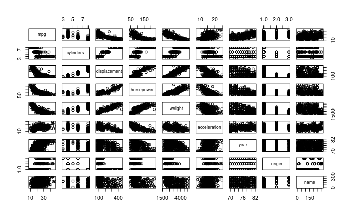

```r
pairs(Auto)
```

Positive relationships: (displacement, horsepower, weight,cylinders), mpg and year Negative relationship: prev.() and mpg, origin, acceleration

6. Suppose that we wish to predict gas mileage ( mpg ) on the basis of the other variables. Do your plots suggest that any of the other variables might be useful in predicting mpg ? Justify your answer.

Displacement, horsepower and weight. Maybe origin.

# Chapter 3 - Exercise 8

1. Use the lm() function to perform a simple linear regression with mpg as the response and horsepower as the predictor. Use the summary() function to print the results. Comment on the output. For example:

```r
A=lm(mpg~horsepower, Auto)
summary(A)
```

```
Call:
lm(formula = mpg ~ horsepower, data = Auto)

Residuals:
     Min       1Q   Median       3Q      Max
-13.5710  -3.2592  -0.3435   2.7630  16.9240

Coefficients:
             Estimate Std. Error t value Pr(>|t|)
(Intercept) 39.935861   0.717499   55.66   <2e-16 ***
horsepower  -0.157845   0.006446  -24.49   <2e-16 ***
---
Signif. codes:  0 ‘***’ 0.001 ‘**’ 0.01 ‘*’ 0.05 ‘.’ 0.1 ‘ ’ 1

Residual standard error: 4.906 on 390 degrees of freedom
Multiple R-squared:  0.6059,    Adjusted R-squared:  0.6049
F-statistic: 599.7 on 1 and 390 DF,  p-value: < 2.2e-16
```

1. Is there a relationship between the predictor and the response?

Yes, because p-value of F-statistic is low.

2. How strong is the relationship between the predictor and the response?

Yes, because p-value of predictor is low.

3. Is the relationship between the predictor and the response positive or negative?

It is negative, since the coefficient is -0,157845.

4. What is the predicted mpg associated with a horsepower of 98? What are the associated 95 % confidence and prediction intervals?

predicted mpg associated with a horsepower of 98: 39,93-0,15*98

```r
predict (A,data.frame(horsepower=98),interval='confidence')
```

```
       fit      lwr      upr
1 24.46708 23.97308 24.96108
```

```r
predict (A,data.frame(horsepower=(c(98))),interval='prediction')
```

```
       fit     lwr      upr
1 24.46708 14.8094 34.12476
```

2. Plot the response and the predictor. Use the abline() function to display the least squares regression line.

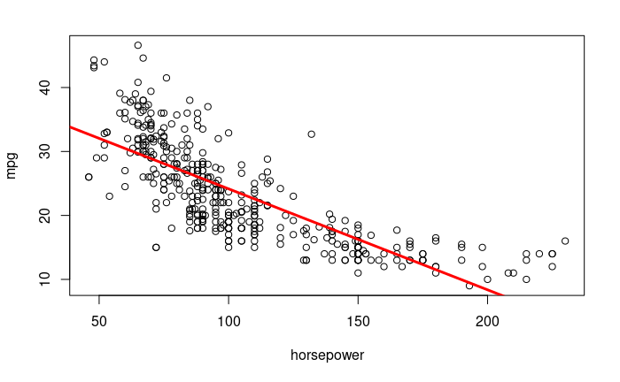

```r
plot(horsepower, mpg)
abline(A,lwd=3,col='red')
```

3. Use the plot() function to produce diagnostic plots of the least squares regression fit. Comment on any problems you see with the fit.

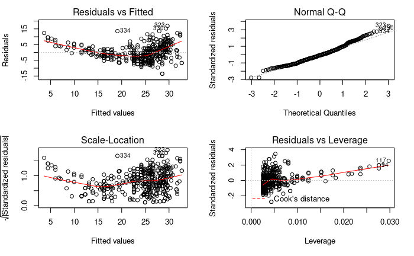

```r
par (mfrow = c(2, 2))#Splits the screen
plot(A)
```

# Chapter 3 - Exercise 9

1. Produce a scatterplot matrix which includes all of the variables in the data set.

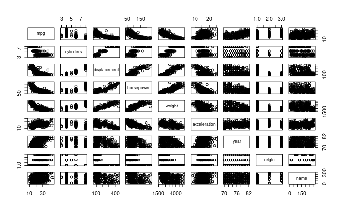

```r
pairs(Auto)
```

2. Compute the matrix of correlations between the variables using the function cor() . You will need to exclude the name variable, which is qualitative.

```r
cor(Auto[-9])
```

```
                    mpg  cylinders displacement horsepower     weight acceleration       year     origin
mpg           1.0000000 -0.7776175   -0.8051269 -0.7784268 -0.8322442    0.4233285  0.5805410  0.5652088
cylinders    -0.7776175  1.0000000    0.9508233  0.8429834  0.8975273   -0.5046834 -0.3456474 -0.5689316
displacement -0.8051269  0.9508233    1.0000000  0.8972570  0.9329944   -0.5438005 -0.3698552 -0.6145351
horsepower   -0.7784268  0.8429834    0.8972570  1.0000000  0.8645377   -0.6891955 -0.4163615 -0.4551715
weight       -0.8322442  0.8975273    0.9329944  0.8645377  1.0000000   -0.4168392 -0.3091199 -0.5850054
acceleration  0.4233285 -0.5046834   -0.5438005 -0.6891955 -0.4168392    1.0000000  0.2903161  0.2127458
year          0.5805410 -0.3456474   -0.3698552 -0.4163615 -0.3091199    0.2903161  1.0000000  0.1815277
origin        0.5652088 -0.5689316   -0.6145351 -0.4551715 -0.5850054    0.2127458  0.1815277  1.0000000
```

High correlation: cylinders and displacement (0.9508233), weight and displacement (0.9329944), displacement and horsepower (0.8972570), weight and horsepower (0.8645377), cylinders and horsepower (0.8429834), weight and mpg (-0.8322442), mpg and displacement (-0.8051269)

3. Use the lm() function to perform a multiple linear regression with mpg as the response and all other variables except name as the predictors. Use the summary() function to print the results. Comment on the output. For instance:

```r
B=lm(mpg~cylinders+displacement+horsepower+weight+acceleration+year+origin)
summary(B)
```

```
Call:
lm(formula = mpg ~ cylinders + displacement + horsepower + weight +
    acceleration + year + origin)

Residuals:
    Min      1Q  Median      3Q     Max
-9.5903 -2.1565 -0.1169  1.8690 13.0604

Coefficients:
               Estimate Std. Error t value Pr(>|t|)
(Intercept)  -17.218435   4.644294  -3.707  0.00024 ***
cylinders     -0.493376   0.323282  -1.526  0.12780
displacement   0.019896   0.007515   2.647  0.00844 **
horsepower    -0.016951   0.013787  -1.230  0.21963
weight        -0.006474   0.000652  -9.929  < 2e-16 ***
acceleration   0.080576   0.098845   0.815  0.41548
year           0.750773   0.050973  14.729  < 2e-16 ***
origin         1.426141   0.278136   5.127 4.67e-07 ***
---
Signif. codes:  0 ‘***’ 0.001 ‘**’ 0.01 ‘*’ 0.05 ‘.’ 0.1 ‘ ’ 1

Residual standard error: 3.328 on 384 degrees of freedom
Multiple R-squared:  0.8215,    Adjusted R-squared:  0.8182
F-statistic: 252.4 on 7 and 384 DF,  p-value: < 2.2e-16
```

1. Is there a relationship between the predictors and the response?

Yes, because p-value of F-statistic is low.

2. Which predictors appear to have a statistically significant relationship to the response?

3. What does the coefficient for the year variable suggest?

Positive relationship between year and mpg. For an increment of a year, mpg grows 0.750773 units.

4. Use the plot() function to produce diagnostic plots of the linear regression fit. Comment on any problems you see with the fit. Do the residual plots suggest any unusually large outliers? Does the leverage plot identify any observations with unusually high leverage?

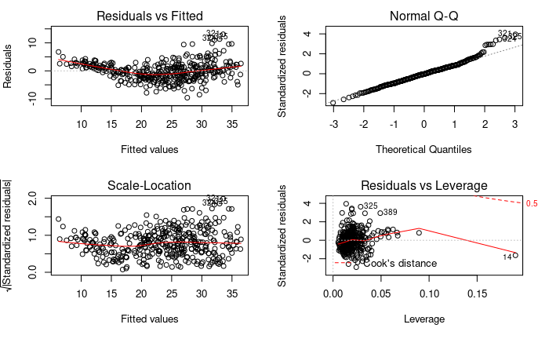

```r
par (mfrow = c(2,2))
plot(B)
```

Residuals vs fitted values -> Outliers: 324, 325 and 321. It seems there is no linear relationship because there is no pattern in residuals.

In sqrt(|st res|) vs fitted values we see the same outliers.

High -leverage points: 14, also 389 as outlier.

5. Use the * and : symbols to fit linear regression models with interaction effects. Do any interactions appear to be statistically significant?

We leave out the non-significant variables:

Variable, Estimate Std. Error, t value, Pr(>|t|)  
cylinders -0.493376 0.323282 -1.526 0.12780  
horsepower -0.016951 0.013787 -1.230 0.21963  
acceleration 0.080576 0.098845 0.815 0.41548

```r
C=lm(mpg~+displacement+weight+year+origin)
summary(C)
```

```
Call:
lm(formula = mpg ~ +displacement + weight + year + origin)

Residuals:
    Min      1Q  Median      3Q     Max
-9.8102 -2.1129 -0.0388  1.7725 13.2085

Coefficients:
               Estimate Std. Error t value Pr(>|t|)
(Intercept)  -1.861e+01  4.028e+00  -4.620 5.25e-06 ***
displacement  5.588e-03  4.768e-03   1.172    0.242
weight       -6.575e-03  5.571e-04 -11.802  < 2e-16 ***
year          7.714e-01  4.981e-02  15.486  < 2e-16 ***
origin        1.226e+00  2.670e-01   4.593 5.92e-06 ***
---
Signif. codes:  0 ‘***’ 0.001 ‘**’ 0.01 ‘*’ 0.05 ‘.’ 0.1 ‘ ’ 1

Residual standard error: 3.346 on 387 degrees of freedom
Multiple R-squared:  0.8181,    Adjusted R-squared:  0.8162
F-statistic: 435.1 on 4 and 387 DF,  p-value: < 2.2e-16
```

We also take out displacement.

```r
D=lm(mpg~weight+year+origin)
summary(D)
```

```
Call:
lm(formula = mpg ~ weight + year + origin)

Residuals:
    Min      1Q  Median      3Q     Max
-9.9440 -2.0948 -0.0389  1.7255 13.2722

Coefficients:
              Estimate Std. Error t value Pr(>|t|)
(Intercept) -1.805e+01  4.001e+00  -4.510 8.60e-06 ***
weight      -5.994e-03  2.541e-04 -23.588  < 2e-16 ***
year         7.571e-01  4.832e-02  15.668  < 2e-16 ***
origin       1.150e+00  2.591e-01   4.439 1.18e-05 ***
---
Signif. codes:  0 ‘***’ 0.001 ‘**’ 0.01 ‘*’ 0.05 ‘.’ 0.1 ‘ ’ 1

Residual standard error: 3.348 on 388 degrees of freedom
Multiple R-squared:  0.8175,    Adjusted R-squared:  0.816
F-statistic: 579.2 on 3 and 388 DF,  p-value: < 2.2e-16
```

Model with weight*displacement interaction:

```r
E=lm(mpg~displacement*weight+year+origin)
summary(E)
```

```
Call:
lm(formula = mpg ~ displacement * weight + year + origin)

Residuals:
     Min       1Q   Median       3Q      Max
-10.6119  -1.7290  -0.0115   1.5609  12.5584

Coefficients:
                      Estimate Std. Error t value Pr(>|t|)
(Intercept)         -8.007e+00  3.798e+00  -2.108   0.0357 *
displacement        -7.148e-02  9.176e-03  -7.790 6.27e-14 ***
weight              -1.054e-02  6.530e-04 -16.146  < 2e-16 ***
year                 8.194e-01  4.518e-02  18.136  < 2e-16 ***
origin               3.567e-01  2.574e-01   1.386   0.1666
displacement:weight  2.104e-05  2.214e-06   9.506  < 2e-16 ***
---
Signif. codes:  0 ‘***’ 0.001 ‘**’ 0.01 ‘*’ 0.05 ‘.’ 0.1 ‘ ’ 1

Residual standard error: 3.016 on 386 degrees of freedom
Multiple R-squared:  0.8526,    Adjusted R-squared:  0.8507
F-statistic: 446.5 on 5 and 386 DF,  p-value: < 2.2e-16
```

Result: origin seems less important and displacement seems more important than before. However, RSS grows a little and adjusted R-squared decreases when we take it out:

```r
F=lm(mpg~displacement*weight+year)
summary(F)
```

```
Call:
lm(formula = mpg ~ displacement * weight + year)

Residuals:
     Min       1Q   Median       3Q      Max
-10.4068  -1.8337   0.0107   1.5543  12.8164

Coefficients:
                      Estimate Std. Error t value Pr(>|t|)
(Intercept)         -6.379e+00  3.616e+00  -1.764   0.0785 .
displacement        -7.682e-02  8.338e-03  -9.214   <2e-16 ***
weight              -1.077e-02  6.327e-04 -17.025   <2e-16 ***
year                 8.185e-01  4.523e-02  18.096   <2e-16 ***
displacement:weight  2.213e-05  2.072e-06  10.683   <2e-16 ***
---
Signif. codes:  0 ‘***’ 0.001 ‘**’ 0.01 ‘*’ 0.05 ‘.’ 0.1 ‘ ’ 1

Residual standard error: 3.019 on 387 degrees of freedom
Multiple R-squared:  0.8519,    Adjusted R-squared:  0.8503
F-statistic: 556.4 on 4 and 387 DF,  p-value: < 2.2e-16
```

6. Try a few different transformations of the variables, such as log(X), √X, X^2 . Comment on your findings.

We take model from exercise 8 (linear regression with horsepower)

```r
summary(A)
```

```
Call:
lm(formula = mpg ~ horsepower, data = Auto)

Residuals:
     Min       1Q   Median       3Q      Max
-13.5710  -3.2592  -0.3435   2.7630  16.9240

Coefficients:
             Estimate Std. Error t value Pr(>|t|)
(Intercept) 39.935861   0.717499   55.66   <2e-16 ***
horsepower  -0.157845   0.006446  -24.49   <2e-16 ***
---
Signif. codes:  0 ‘***’ 0.001 ‘**’ 0.01 ‘*’ 0.05 ‘.’ 0.1 ‘ ’ 1

Residual standard error: 4.906 on 390 degrees of freedom
Multiple R-squared:  0.6059,    Adjusted R-squared:  0.6049
F-statistic: 599.7 on 1 and 390 DF,  p-value: < 2.2e-16
```

We try with x²:

```r
G=lm(mpg~horsepower+I(horsepower^2))
summary(G)
```

```
Call:
lm(formula = mpg ~ horsepower + I(horsepower^2))

Residuals:
     Min       1Q   Median       3Q      Max
-14.7135  -2.5943  -0.0859   2.2868  15.8961

Coefficients:
                  Estimate Std. Error t value Pr(>|t|)
(Intercept)     56.9000997  1.8004268   31.60   <2e-16 ***
horsepower      -0.4661896  0.0311246  -14.98   <2e-16 ***
I(horsepower^2)  0.0012305  0.0001221   10.08   <2e-16 ***
---
Signif. codes:  0 ‘***’ 0.001 ‘**’ 0.01 ‘*’ 0.05 ‘.’ 0.1 ‘ ’ 1

Residual standard error: 4.374 on 389 degrees of freedom
Multiple R-squared:  0.6876,    Adjusted R-squared:  0.686
F-statistic:   428 on 2 and 389 DF,  p-value: < 2.2e-16
```

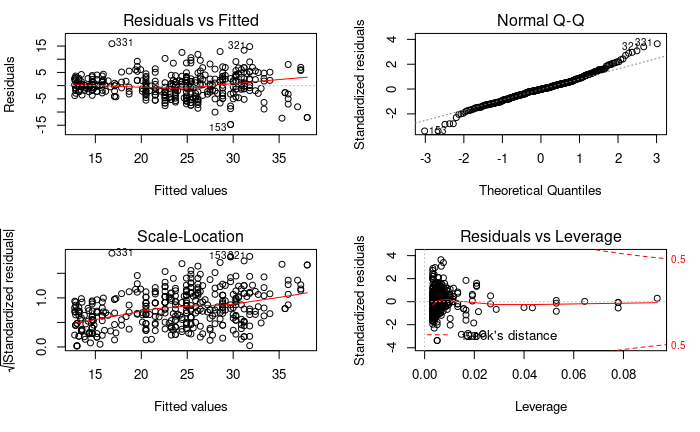

```r
par (mfrow = c(2,2))
plot(G)
```

Now we do not observe a bell form in residuals. Comparison:

```r
anova(A,G)
```

```
Analysis of Variance Table

Model 1: mpg ~ horsepower
Model 2: mpg ~ horsepower + I(horsepower^2)
  Res.Df    RSS Df Sum of Sq      F    Pr(>F)
1    390 9385.9
2    389 7442.0  1    1943.9 101.61 < 2.2e-16 ***
---
Signif. codes:  0 ‘***’ 0.001 ‘**’ 0.01 ‘*’ 0.05 ‘.’ 0.1 ‘ ’ 1
```

Result interpretation (Page 116) The anova() function performs a hypothesis test comparing the two models. The null hypothesis is that the two models fit the data equally well, and the alternative hypothesis is that the full model is superior. Here the F -statistic is 101 and the associated p-value is virtually zero. This provides very clear evidence that the model containing the predictors horsepower and horsepower² is far superior to the model that only contains the predictor hosepower. This is not surprising, since earlier we saw evidence for non-linearity in the relationship between mpg and horsepower.

We use poly until 5th power for the same model:

```r
H=lm(mpg~poly(horsepower,5))
summary(H)
```

```
Call:
lm(formula = mpg ~ poly(horsepower, 5))

Residuals:
     Min       1Q   Median       3Q      Max
-15.4326  -2.5285  -0.2925   2.1750  15.9730

Coefficients:
                      Estimate Std. Error t value Pr(>|t|)
(Intercept)            23.4459     0.2185 107.308  < 2e-16 ***
poly(horsepower, 5)1 -120.1377     4.3259 -27.772  < 2e-16 ***
poly(horsepower, 5)2   44.0895     4.3259  10.192  < 2e-16 ***
poly(horsepower, 5)3   -3.9488     4.3259  -0.913  0.36190
poly(horsepower, 5)4   -5.1878     4.3259  -1.199  0.23117
poly(horsepower, 5)5   13.2722     4.3259   3.068  0.00231 **
---
Signif. codes:  0 ‘***’ 0.001 ‘**’ 0.01 ‘*’ 0.05 ‘.’ 0.1 ‘ ’ 1

Residual standard error: 4.326 on 386 degrees of freedom
Multiple R-squared:  0.6967,    Adjusted R-squared:  0.6928
F-statistic: 177.4 on 5 and 386 DF,  p-value: < 2.2e-16
```

If we consider a model with powers 1, 2 and 5, we see than p-value of horsepower⁵ increases, but the RSS, R² and F-statisctic do not improve so much with respect to the cuadratic model:

```r
I=lm(mpg~horsepower+I(horsepower^2)+I(horsepower^5))
summary(I)
```

```
Call:
lm(formula = mpg ~ horsepower + I(horsepower^2) + I(horsepower^5))

Residuals:
     Min       1Q   Median       3Q      Max
-14.7245  -2.4246  -0.1375   2.1939  15.8498

Coefficients:
                  Estimate Std. Error t value Pr(>|t|)
(Intercept)      5.975e+01  3.280e+00  18.215  < 2e-16 ***
horsepower      -5.315e-01  7.012e-02  -7.580 2.57e-13 ***
I(horsepower^2)  1.595e-03  3.712e-04   4.297 2.19e-05 ***
I(horsepower^5) -1.326e-11  1.275e-11  -1.040    0.299
---
Signif. codes:  0 ‘***’ 0.001 ‘**’ 0.01 ‘*’ 0.05 ‘.’ 0.1 ‘ ’ 1

Residual standard error: 4.373 on 388 degrees of freedom
Multiple R-squared:  0.6884,    Adjusted R-squared:  0.686
F-statistic: 285.8 on 3 and 388 DF,  p-value: < 2.2e-16
```

# Chapter 4 - Exercise 14

In this problem, you will develop a model to predict whether a given car gets high or low gas mileage based on the Auto data set. (a) Create a binary variable, mpg01 , that contains a 1 if mpg contains a value above its median, and a 0 if mpg contains a value below its median. You can compute the median using the median() function. Note you may find it helpful to use the data.frame() function to create a single data set containing both mpg01 and the other Auto variables.

```r
M=median(mpg)
mpg01 <- rep(1, length(mpg))
mpg01[mpg<median(mpg)] <- 0
detach(Auto)
DFmpg01 <- data.frame(mpg01, Auto[, -1])
attach(DFmpg01)
```

2. Explore the data graphically in order to investigate the association between mpg01 and the other features. Which of the other features seem most likely to be useful in predicting mpg01? Scatterplots and boxplots may be useful tools to answer this question. Describe your findings.

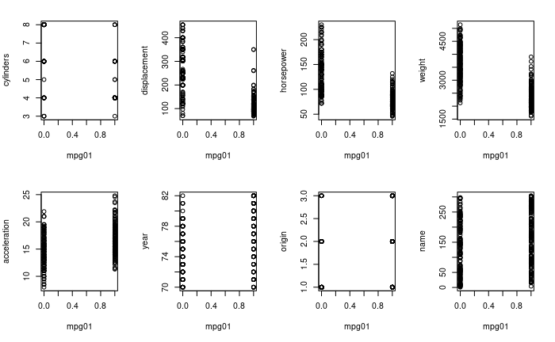

```r
par (mfrow = c(2, 4))
for (i in 2:9){
  plot(mpg01,DFmpg01[,i], ylab=names(Auto[i]))
}
```

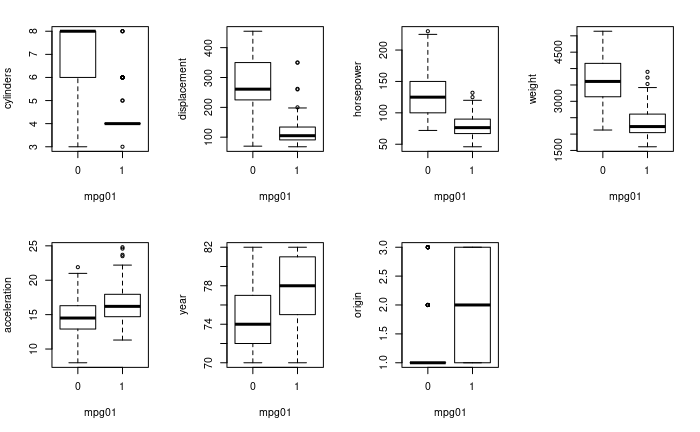

```r
par (mfrow = c(2, 4))
for (i in 2:8){
  plot(as.factor(mpg01),DFmpg01[,i], xlab="mpg01", ylab=names(Auto[i]))
}
```

3. Split the data into a training set and a test set.

```r
train=(year<80)
DFmpg01.Test=DFmpg01[!train,]#data with train = false, ie. year>=2009
MPG01.Test=mpg01[!train]
```

4. Perform LDA on the training data in order to predict mpg01 using the variables that seemed most associated with mpg01 in (b). What is the test error of the model obtained?

```r
library(MASS)
#Fitting of the LDA model
lda.fit <- lda(mpg01 ~ cylinders+displacement+horsepower+weight, data=DFmpg01, subset=train)
lda.pred <- predict(lda.fit, DFmpg01.Test)
lda.class <- lda.pred$class

table(lda.class, MPG01.Test)
```

```
         MPG01.Test
lda.class  0  1
        0  5 11
        1  0 69
```

```r
mean(lda.class!=MPG01.Test)
```

```
[1] 0.1294118
```

5. Perform QDA on the training data in order to predict mpg01 using the variables that seemed most associated with mpg01 in (b). What is the test error of the model obtained?

```r
QDA.Model=qda(mpg01~cylinders, data=DFmpg01, subset=train)
QDA.pred=predict(QDA.Model, DFmpg01.Test)
names(QDA.pred)
```

```
[1] "class"     "posterior"
```

```r
QDA.MPG01=QDA.pred$class
table(QDA.MPG01, MPG01.Test)
```

```
         MPG01.Test
QDA.MPG01  0  1
        0  5  8
        1  0 72
```

```r
mean(QDA.MPG01!=MPG01.Test)
```

```
[1] 0.09411765
```

6. Perform logistic regression on the training data in order to predict mpg01 using the variables that seemed most associated with mpg01 in (b). What is the test error of the model obtained?

```r
LR=glm(mpg01~cylinders, data=DFmpg01, family=binomial,subset=train)
summary(LR)
```

```
Call:
glm(formula = mpg01 ~ cylinders, family = binomial, data = DFmpg01,
    subset = train)

Deviance Residuals:
    Min       1Q   Median       3Q      Max
-2.4987  -0.5068  -0.0967   0.6673   3.2767

Coefficients:
            Estimate Std. Error z value Pr(>|z|)
(Intercept)   8.1409     0.8867   9.181   <2e-16 ***
cylinders    -1.6881     0.1888  -8.939   <2e-16 ***
---
Signif. codes:  0 ‘***’ 0.001 ‘**’ 0.01 ‘*’ 0.05 ‘.’ 0.1 ‘ ’ 1

(Dispersion parameter for binomial family taken to be 1)

    Null deviance: 407.08  on 306  degrees of freedom
Residual deviance: 191.09  on 305  degrees of freedom
AIC: 195.09

Number of Fisher Scoring iterations: 6
```

```r
LR.Prob=predict(LR,DFmpg01.Test, type='response')
LR.pred =rep (0, length(MPG01.Test))
LR.pred[LR.Prob>.5] = 1
table(LR.pred, MPG01.Test)
```

```
       MPG01.Test
LR.pred  0  1
      0  5  9
      1  0 71
```

```r
mean(LR.pred!=MPG01.Test)
```

```
[1] 0.1058824
```

7. Perform naive Bayes on the training data in order to predict mpg01 using the variables that seemed most associated with mpg01 in (b). What is the test error of the model obtained?

```r
library(e1071)
```

```r
#Fitting of the Naive Bayes model
NB=naiveBayes(mpg01~cylinders, data=DFmpg01, subset=train)
#Prediction and confusion matrix
NB.pred=predict(NB, DFmpg01.Test)
table(NB.pred, MPG01.Test)
```

```
       MPG01.Test
NB.pred  0  1
      0  5  8
      1  0 72
```

```r
mean(NB.pred!=MPG01.Test)
```

```
[1] 0.09411765
```

8. Perform KNN on the training data, with several values of K, in order to predict mpg01 . Use only the variables that seemed most associated with mpg01 in (b). What test errors do you obtain? Which value of K seems to perform the best on this data set?

```r
library(class)
train.X <- cbind(cylinders, displacement, horsepower, weight)[train,]
test.X <- cbind(cylinders, displacement, horsepower, weight)[!train,]
train.DFmpg01 <- mpg01[train]
set.seed(1)
for (i in 1:100){
  KNN.pred=knn(train.X, test.X, train.DFmpg01, k=i)
  table(KNN.pred, MPG01.Test)
  if (mean(KNN.pred==MPG01.Test)>=0.82){
    print(i)
    print(mean(KNN.pred==MPG01.Test))
  }
}
```

```
[1] 21
[1] 0.8235294
[1] 22
[1] 0.8235294
[1] 23
[1] 0.8235294
[1] 24
[1] 0.8235294
[1] 25
[1] 0.8235294
[1] 26
[1] 0.8352941
[1] 27
[1] 0.8235294
[1] 28
[1] 0.8235294
[1] 29
[1] 0.8235294
[1] 32
[1] 0.8352941
```